# Primeros pasos en R

Los-Palmas

2023-03-29

## Definición de variables numéricas

para definir variables numericas basta con darle un nombre a la variable y poner la flecha de asignación seguida del valor numérico que queremos asignar. en la ventana superior derecha aparecerá la variable con su valor

```r
ca<-16
ca
```

```
## [1] 16
```

### VECTORES

Los vectores son otra estructura de datos de R que a diferencia de las variables que vimos antes, alojan una colección de valores. Desde el punto de vista de objetos una variable simple es un vector que solo tiene un elemento.

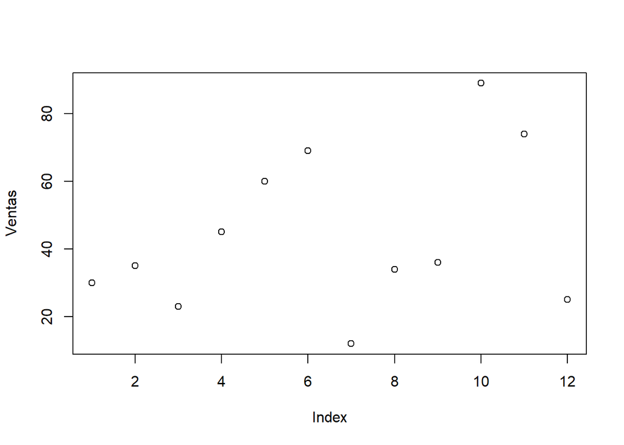

```r
Ventas <- c (30,35,23,45,60,69,12,34,36,89,74,25)
plot(Ventas)
```

Quisiera saber cuál es el nivel promedio de ventas anuales y el desvío estandar.

```r
mean (Ventas)
```

```
## [1] 44.33333
```

```r
sd (Ventas)
```

```
## [1] 23.49597
```

Queremos generar unos datos para meter en un simulador que representen a nuestra empresa. Vamos a generar 500 datos con el mismo promedio y desvío estándar.

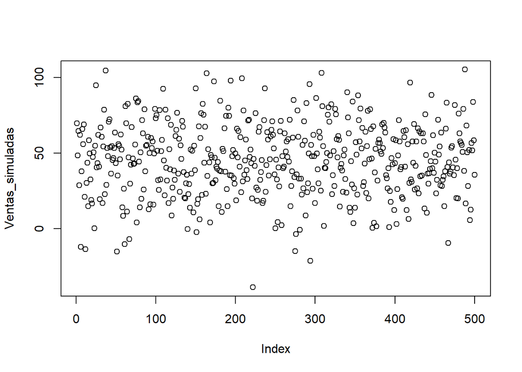

```r
Ventas_simuladas<-rnorm(500,44.33333,23.49597)
plot(Ventas_simuladas)
```

Qué probabilidad tengo de que las ventas sean menores a 30

```r
pnorm(30,44.33,23.49)
```

```
## [1] 0.2709154
```

## VARIABLES DE TIPO LISTA

Las variables de tipo lista son vectores pero que se generan con el comando “scan()”. Como scan es un comando interactivo no podemos colocarlo dentro de un documento Rmarkdown. Sólo podemos ejecutar en la ventana de consola el comando.

```
compras <-scan()
```

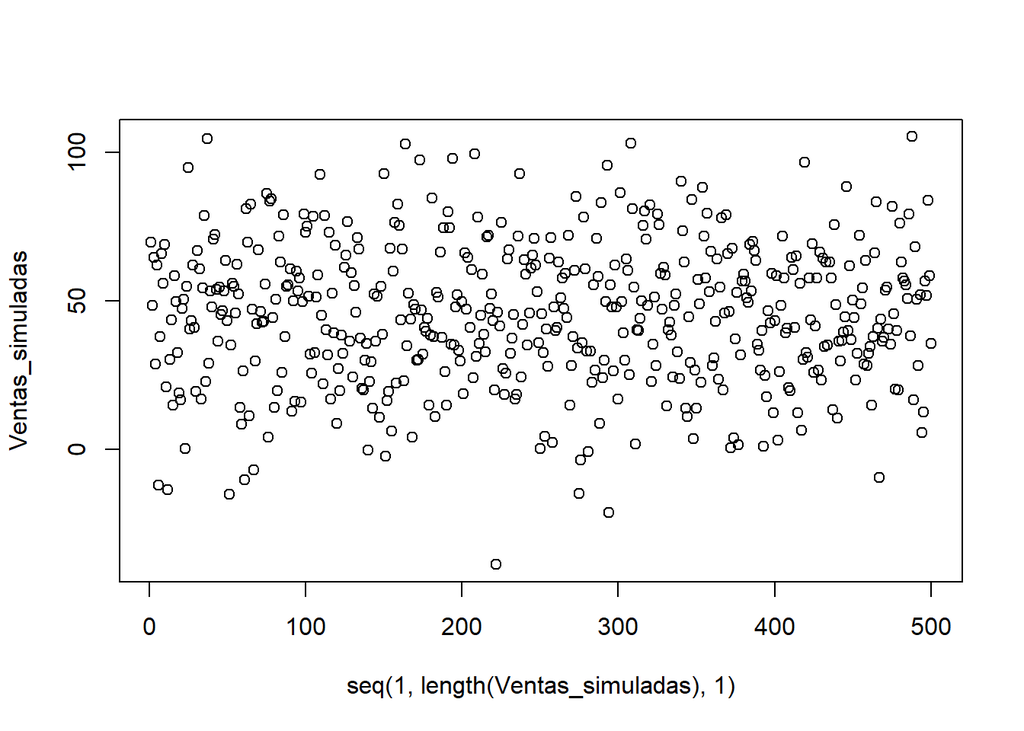

```r
plot(seq(1,length(Ventas_simuladas),1),Ventas_simuladas)
```

## MÉTODOS ALTERNATIVOS DE GENERAR SECUENCIAS

```r
impuestos<-0
impuestos[1] <- 0
for (i in 2:24) {
impuestos[i] <- impuestos[i-1]+2*i
impuestos
}
impuestos
```

```
##  [1]   0   4  10  18  28  40  54  70  88 108 130 154 180 208 238 270 304 340 378
## [20] 418 460 504 550 598
```

De la lista ventas_simuladas ¿Cuántos valores son superiores a 40?

```r
indice <- which(Ventas_simuladas > 40)
indice
```

```
##   [1]   1   2   3   5   8   9  10  14  16  17  21  22  24  25  26  27  28  29
##  [19]  31  32  34  35  37  39  40  41  42  43  45  46  47  48  49  50  53  54
##  [37]  55  56  57  62  63  65  66  69  70  71  72  73  74  75  77  78  79  81
##  [55]  83  84  86  88  89  90  92  94  95  96  98  99 100 101 102 105 107 108
##  [73] 109 110 112 113 115 117 119 125 126 127 129 131 132 133 134 144 146 148
##  [91] 150 154 156 157 159 160 161 162 164 166 167 169 170 173 174 176 178 181
## [109] 184 185 186 188 191 192 194 196 197 200 202 203 204 205 206 208 210 212
## [127] 213 216 217 218 219 220 223 224 225 229 230 233 236 237 239 240 241 243
## [145] 244 245 246 247 248 251 254 256 257 259 260 261 262 263 264 265 266 267
## [163] 268 272 273 278 279 284 286 287 289 292 293 295 296 298 299 301 302 305
## [181] 306 308 309 310 312 314 315 316 317 318 319 320 323 325 326 327 328 329
## [199] 330 332 333 336 337 340 341 342 345 347 351 352 354 355 356 357 358 359
## [217] 362 363 365 366 368 369 370 371 373 376 379 380 381 382 383 384 385 386
## [235] 387 388 392 396 397 398 400 401 404 405 406 408 411 412 413 414 416 419
## [253] 422 423 424 426 427 429 431 433 435 436 438 439 445 446 447 448 450 451
## [271] 454 455 456 458 464 465 466 468 471 472 473 475 476 478 480 481 482 483
## [289] 484 485 486 488 490 491 493 496 497 498 499
```

```r
indice <-  which(Ventas_simuladas > 40)
indice
```

```
##   [1]   1   2   3   5   8   9  10  14  16  17  21  22  24  25  26  27  28  29
##  [19]  31  32  34  35  37  39  40  41  42  43  45  46  47  48  49  50  53  54
##  [37]  55  56  57  62  63  65  66  69  70  71  72  73  74  75  77  78  79  81
##  [55]  83  84  86  88  89  90  92  94  95  96  98  99 100 101 102 105 107 108
##  [73] 109 110 112 113 115 117 119 125 126 127 129 131 132 133 134 144 146 148
##  [91] 150 154 156 157 159 160 161 162 164 166 167 169 170 173 174 176 178 181
## [109] 184 185 186 188 191 192 194 196 197 200 202 203 204 205 206 208 210 212
## [127] 213 216 217 218 219 220 223 224 225 229 230 233 236 237 239 240 241 243
## [145] 244 245 246 247 248 251 254 256 257 259 260 261 262 263 264 265 266 267
## [163] 268 272 273 278 279 284 286 287 289 292 293 295 296 298 299 301 302 305
## [181] 306 308 309 310 312 314 315 316 317 318 319 320 323 325 326 327 328 329
## [199] 330 332 333 336 337 340 341 342 345 347 351 352 354 355 356 357 358 359
## [217] 362 363 365 366 368 369 370 371 373 376 379 380 381 382 383 384 385 386
## [235] 387 388 392 396 397 398 400 401 404 405 406 408 411 412 413 414 416 419
## [253] 422 423 424 426 427 429 431 433 435 436 438 439 445 446 447 448 450 451
## [271] 454 455 456 458 464 465 466 468 471 472 473 475 476 478 480 481 482 483
## [289] 484 485 486 488 490 491 493 496 497 498 499
```

```r
Ventas_simuladas[indice]
```

```
##   [1]  69.89693  48.37083  64.66931  62.05577  66.02729  55.91395  68.99993
##   [8]  43.50805  58.60240  49.82006  47.47331  50.61368  54.81906  95.04875
##  [15]  40.57517  43.45300  62.05619  40.93694  67.04267  60.74453  54.33802
##  [22]  78.76024 104.78630  53.28906  47.90548  70.86471  72.46114  53.98804
##  [29]  54.51686  45.39545  46.57804  53.27600  63.70306  43.30333  55.81837
##  [36]  54.99267  45.81664  62.42149  52.34225  81.12767  69.70069  82.74046
##  [43]  47.09954  42.35702  67.11825  46.30780  42.82614  43.09710  55.64817
##  [50]  86.34615  83.77956  84.53103  44.47109  50.59357  71.71572  63.01390
##  [57]  78.93034  54.87259  55.37238  60.79428  50.11037  59.96365  53.25299
##  [64]  57.77643  49.80966  79.40322  73.23415  75.25875  51.46634  78.43476
##  [71]  51.27295  58.65166  92.74300  45.23502  78.69775  40.30419  73.13106
##  [78]  52.59784  68.81490  61.31561  65.40985  76.72795  59.60487  55.23345
##  [85]  46.26007  71.35496  67.41621  52.22632  51.44259  54.79072  92.92439
##  [92]  67.80126  60.01465  76.33653  82.60781  75.54696  43.55875  67.39811
##  [99] 103.02927  52.63017  43.83219  48.75579  47.26169  97.48535  46.93883
```

[output cut: 28 more lines]

```r
length(indice)
```

```
## [1] 299
```

```r
sum(Ventas_simuladas[indice])
```

```
## [1] 18158.37
```

```r
A <- 0
 A[1] <- 0
 A[2] <- 1
 A[3] <- A[1]+A[2]
 for (i in 3:31) {A[i] <- A[i-1]+A[i-2]}
A
```

```
##  [1]      0      1      1      2      3      5      8     13     21     34
## [11]     55     89    144    233    377    610    987   1597   2584   4181
## [21]   6765  10946  17711  28657  46368  75025 121393 196418 317811 514229
## [31] 832040
```